# FigureYa109subtypeGSEA

小丫画图出品

2019-6-27

欢迎关注“小丫画图”公众号，同名知识星球等你加入

小丫微信: epigenomics E-mail: figureya@126.com

作者：大鱼海棠

单位：Research Center of Biostatistics and Computational Pharmacy, China Pharmaceutical University

小丫编辑校验

## 需求描述

多组的富集分析及结果展示，用clusterProfiler做GSEA，挑选各组特异性top通路，画出paper里这样的对角热图。图中横坐标的6列对应6个亚型（分组），右侧文字的背景色对应6个亚组（分组）富集的通路。

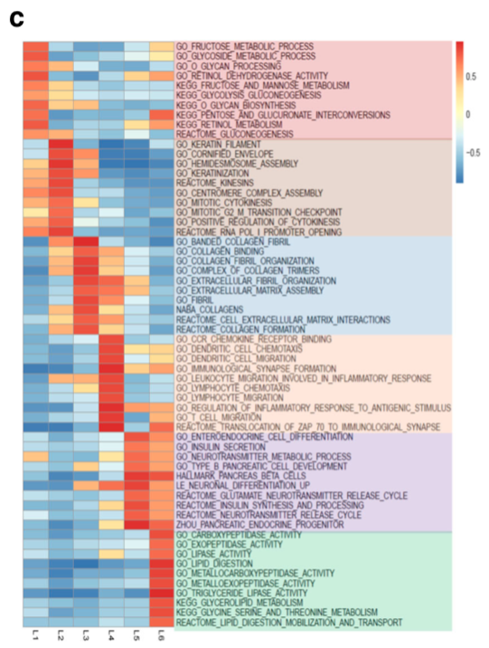

出自https://bmccancer.biomedcentral.com/articles/10.1186/s12885-018-4546-8

Fig. 3c GSEA analysis reveals distinct enriched gene sets between subtypes. In the heatmap, rows are defined by the selected 60 gene sets, and columns by consensus scores for each subtype. Subtype enriched gene sets are highlighted by different color, L1 (light red), L2 (light brown), L3 (light blue), L4 (light orange), L5 (light purple) and L6 (light green).

## 应用场景

多组富集分析结果，画在一起对比展示，就能同时看到同一通路在其他分组里的富集状态。

## 环境设置

使用国内镜像安装包

```r
options("repos"= c(CRAN="https://mirrors.tuna.tsinghua.edu.cn/CRAN/"))
options(BioC_mirror="http://mirrors.ustc.edu.cn/bioc/")
BiocManager::install("clusterProfiler")
BiocManager::install("GSVA")
```

加载包

```r
library(clusterProfiler)
```

```r
library(GSVA)
library(pheatmap)
library(gplots)
Sys.setenv(LANGUAGE = "en") #显示英文报错信息
options(stringsAsFactors = FALSE) #禁止chr转成factor
```

## 输入文件

以TCGA皮肤黑色素瘤为例，输入数据包括cBioPortal下载的标准化表达谱以及TCGA定义的3种亚型（keratin, immune，MITF-low），这里按亚型分为3组，将对比展示这三种亚型的富集分析。

easy_input_expr.csv，表达矩阵

easy_input_subtype.txt，分组信息，此处是3种亚型

```r
expr <- read.csv("easy_input_expr.csv", check.names = F, row.names = 1)
expr[1:3,1:3]
```

```
##           SKCM-A1PU SKCM-A1PV SKCM-A1PX
## UBE2Q2P3        0.4       2.1       0.6
## LOC149767       6.6       7.4       6.9
## TIMM23          9.1       9.6       9.6
```

```r
dim(expr)
```

```
## [1] 15278   328
```

```r
subt <- read.table("easy_input_subtype.txt", sep = "\t", check.names = F, stringsAsFactors = F, header = T, row.names = 1)
head(subt)
```

```
##           TCGA_Subtype
## SKCM-A1PU      keratin
## SKCM-A1PV      keratin
## SKCM-A1PX      keratin
## SKCM-A1PZ      keratin
## SKCM-A1Q0       immune
## SKCM-A3DJ      keratin
```

```r
table(subt$TCGA_Subtype)
```

```
##
##   immune  keratin MITF-low
##      168      101       59
```

## 多组差异表达：One vs. Others

做GSEA需要样本中所有基因的排序，这里用的是**每一组 vs. 所有其他组**获得的log2FoldChange。下面将用表达矩阵获得每组基因的log2FoldChange排序。

示例数据样本较多，你的样本可能只有1-3个/组，速度会快很多。

```r
### 自定义函数显示进度 ###
display.progress = function ( index, totalN, breakN=20) {
  if ( index %% ceiling(totalN/breakN)  ==0  ) {
    cat(paste(round(index*100/totalN), "% ", sep=""))
  }
}

n.sub <- length(table(subt$TCGA_Subtype)) # 亚型个数
n.sub.label <- unique(subt$TCGA_Subtype) # 亚型名称

expr <- log2(expr + 1)
treat_list <- ctrl_list <- degs.list <- list() # 初始化列表
for (i in 1:n.sub) {
  cat(paste0(n.sub.label[i], " vs. Others starts!\n"))
  treat_list[[i]] <- rownames(subt)[which(subt$TCGA_Subtype == n.sub.label[i])] # 选取某亚型为treat组
  ctrl_list[[i]] <- rownames(subt)[-which(subt$TCGA_Subtype == n.sub.label[i])] # 选取剩余亚型为control组

  meanA <- meanB <- p <- fc <- lgfc <- c() #初始化向量
  for (k in 1:nrow(expr)) {
    display.progress(index = k,totalN = nrow(expr)) #显示进程
    a <- as.numeric(expr[k,treat_list[[i]]])
    b <- as.numeric(expr[k,ctrl_list[[i]]])
    p <- c(p,t.test(a,b,na.rm=T)$p.value) # 检验表达差异
    meanA <- c(meanA,mean(a)) # treat组基因k表达均值
    meanB <- c(meanB,mean(b)) # control组基因k表达均值
    fc <- c(fc,mean(a)/mean(b)) # 计算foldchange
    lgfc <- c(lgfc,log2(mean(a)/mean(b))) # 计算log2foldchange
  }
  fdr <- p.adjust(p,method = "fdr") # 校正p值

  # 生成差异表达结果，其中log2FoldChange, pvalue, padj模仿DESeq2结果格式
  # 由于差异表达分析不是本众筹的目的，所以这里采用简单的两样本t检验寻找显著差异表达基因。差异表达分析可根据实际数据情况换用limma（例文）, DESeq, DESeq2, edgeR等方法。
  degs <- data.frame(mean_treat=meanA,
                     mean_ctrl=meanB,
                     FoldChange=fc,
                     log2FoldChange=lgfc,
                     pvalue=p,
                     padj=fdr,
                     row.names = rownames(expr),
                     stringsAsFactors = F)

  write.table(degs,paste0(n.sub.label[[i]],"_degs.txt"),sep = "\t",row.names = T,col.names = NA,quote = F)

  degs.list[[n.sub.label[i]]] <- as.data.frame(na.omit(degs))

  cat("\n")
}
```

```
## keratin vs. Others starts!
## 5% 10% 15% 20% 25% 30% 35% 40% 45% 50% 55% 60% 65% 70% 75% 80% 85% 90% 95%
## immune vs. Others starts!
## 5% 10% 15% 20% 25% 30% 35% 40% 45% 50% 55% 60% 65% 70% 75% 80% 85% 90% 95%
## MITF-low vs. Others starts!
## 5% 10% 15% 20% 25% 30% 35% 40% 45% 50% 55% 60% 65% 70% 75% 80% 85% 90% 95%
```

## 自定义分析函数

先自定义一个函数，便于分别计算显著上调的和显著下调的分组的特异性通路。

重要参数说明：

- msigdb为加载的MSigDB数据库，可从GSEA官网下载gmt格式的文件：http://software.broadinstitute.org/gsea/downloads.jsp，此处以c5.all.v6.2.symbols.gmt为例，下载链接：http://software.broadinstitute.org/gsea/msigdb/download_file.jsp?filePath=/resources/msigdb/6.2/c5.all.v6.2.symbols.gmt
- n.top是选取的**top通路集的个数**，默认是10
- mode为寻找模式，up代表上调，dn代表下调，推荐寻找亚型特异性上调通路
- degs.list为配对差异表达基因列表
- subtype.label为亚型名称，顺序及名称必须匹配degs.list
- 其余参数为GSEA参数

```r
subtype_specific_gsea <- function(msigdb=NULL,n.top=10,mode=c("up","down"),degs.list=NULL,subtype.label=NULL,nPerm.gsea=1000,minGSSize.gsea=10,maxGSSize.gsea=500,pvalueCutoff.gsea=1){

  MSigDB <- read.gmt(msigdb)
  GSEA.list <- top.gs <- list() #初始化结果列表

  if(!is.element(mode, c("up", "dn"))) { stop("mode must be up or dn!\n") }

  for (i in 1:n.sub) {
    degs <- degs.list[[n.sub.label[i]]]
    geneList <- degs$log2FoldChange; names(geneList) <- rownames(degs)
    geneList <- sort(geneList,decreasing = T) # ranked gene set

    # 由于GSEA不可重复，所以保存GSEA对象入列表，方便下次调用
    cat(paste0("GSEA for ",subtype.label[i]," starts!\n"))
    GSEA.list[[subtype.label[i]]] <- GSEA(geneList = geneList,
                                        TERM2GENE=MSigDB,
                                        nPerm = nPerm.gsea,
                                        minGSSize = minGSSize.gsea,
                                        maxGSSize = maxGSSize.gsea,
                                        seed = T,
                                        verbose = F,
                                        pvalueCutoff = pvalueCutoff.gsea) # 输出全部的GESA结果

    GSEA.dat <- as.data.frame(GSEA.list[[subtype.label[i]]])

    if(mode == "up") {
      GSEA.dat <- GSEA.dat[order(GSEA.dat$NES,decreasing = T),] # 根据NES降序排列，也就是找特异性上调通路
    } else {
      GSEA.dat <- GSEA.dat[order(GSEA.dat$NES,decreasing = F),] # 根据NES升序排列，也就是找特异性下调通路
    }

    # 输出每一次GSEA结果
    write.table(GSEA.dat,paste0(subtype.label[[i]],"_degs_",mode,"_gsea.txt"),sep = "\t",row.names = T,col.names = NA,quote = F)

    # 亚型特异性top基因集保存入列表
    top.gs[[subtype.label[i]]] <- rownames(GSEA.dat)[1:n.top]
  }

  # 构建GSVA分析需要的gene list
  gs <- list()
  for (i in as.character(unlist(top.gs))) {
    gs[[i]] <- MSigDB[which(MSigDB$ont %in% i),"gene"]
  }

  return(list(mode=mode,top.gs=top.gs,gs=gs))
}
```

## 寻找显著上调的亚型特异性通路(推荐)

运行上面的函数来寻找显著上调的亚型特异性通路。

```r
msigdfFile = "c5.all.v6.2.symbols.gmt"
n.top = 10
mode = "up" #"up"和"dn"二选一
gs.up <- subtype_specific_gsea(msigdb = msigdfFile,
                               n.top = n.top,
                               degs.list = degs.list,
                               subtype.label = n.sub.label,
                               mode = mode)
```

```
## GSEA for keratin starts!
## GSEA for immune starts!
## GSEA for MITF-low starts!
```

```r
# 计算GSVA得分
gsva_gs.up <- gsva(as.matrix(expr), gs.up$gs, method="gsva")
```

```
## Estimating GSVA scores for 30 gene sets.
## Computing observed enrichment scores
## Estimating ECDFs with Gaussian kernels
## Using parallel with 4 cores
##
```

```r
dim(gsva_gs.up)
```

```
## [1]  30 328
```

```r
# 这里是30条通路，说明top通路无重叠

# 每个亚型取均值（也可以换用其他统计量，比如中位数等等）
gsva_gs.up_mean <- data.frame(row.names = rownames(gsva_gs.up))
for (i in n.sub.label) {
  gsva_gs.up_mean <- cbind.data.frame(gsva_gs.up_mean,
                                   data.frame(rowMeans(gsva_gs.up[,rownames(subt)[which(subt$TCGA_Subtype == i)]])))
}
colnames(gsva_gs.up_mean) <- n.sub.label
```

绘制热图（无聚类）

```r
#自定义分组的颜色
jco <- c("#F2CCCC","#E6D8CF","#D5E3F0","#FDE7DA","#E2D6EC", "#CCEFDB")

annRows <- data.frame(subtype=rep(n.sub.label,each=n.top), names = unlist(gs.up$top.gs), stringsAsFactors = F)
annRows <- annRows[!duplicated(annRows$names),]; rownames(annRows) <- annRows$names # 倘若出现一条通路在>=2个亚型中上调，去掉重复值，这种情况在亚型较多的时候会发生

#示例数据是3个分组，有更多组就继续往后添加
annColors <- list(subtype=c("keratin"=jco[1],"immune"=jco[2],"MITF-low"=jco[3]))

filename <- paste0("subtype_specific_top_",mode,"_gsea.pdf")
pheatmap(gsva_gs.up_mean[rownames(annRows),],
         cellwidth = 10, cellheight = 10,
         #color = bluered(64), #自定义颜色
         cluster_rows = F,
         cluster_cols = F,
         border_color = NA, #如果想要边框，就去掉这行
         annotation_row = annRows[,"subtype",drop = F],
         annotation_colors = annColors,
         filename = filename)
```

[figure not shown]

## 寻找显著下调的亚型特异性通路

```r
mode = "dn"
gs.dn <- subtype_specific_gsea(msigdb = msigdfFile,
                               n.top = n.top,
                               degs.list = degs.list,
                               subtype.label = n.sub.label,
                               mode = mode)
```

```
## GSEA for keratin starts!
## GSEA for immune starts!
## GSEA for MITF-low starts!
```

```r
# 计算GSVA得分
gsva_gs.dn <- gsva(as.matrix(expr), gs.dn$gs, method="gsva") # 注意这里只有27条通路了，说明top通路有重叠
```

```
## Estimating GSVA scores for 27 gene sets.
## Computing observed enrichment scores
## Estimating ECDFs with Gaussian kernels
## Using parallel with 4 cores
##
```

```r
# 每个亚型取均值（也可以换用其他统计量，比如中位数等等）
gsva_gs.dn_mean <- data.frame(row.names = rownames(gsva_gs.dn))
for (i in n.sub.label) {
  gsva_gs.dn_mean <- cbind.data.frame(gsva_gs.dn_mean,
                                      data.frame(rowMeans(gsva_gs.dn[,rownames(subt)[which(subt$TCGA_Subtype == i)]])))
}
colnames(gsva_gs.dn_mean) <- n.sub.label
```

绘制热图（无聚类）

```r
annRows <- data.frame(subtype=rep(n.sub.label,each=n.top), names = unlist(gs.dn$top.gs), stringsAsFactors = F)
annRows <- annRows[!duplicated(annRows$names),]; rownames(annRows) <- annRows$names # 倘若出现一条通路在>=2个亚型中下调，去掉重复值，这种情况在亚型较多的时候会发生

#示例数据是3个分组，有更多组就继续往后添加
annColors <- list(subtype=c("keratin"=jco[1],"immune"=jco[2],"MITF-low"=jco[3]))

filename <- paste0("subtype_specific_top_",mode,"_gsea.pdf")
pheatmap(gsva_gs.dn_mean[rownames(annRows),],
         cellwidth = 10, cellheight = 10,
         #color = bluered(64), #自定义颜色
         border_color = NA, #如果想要边框，就去掉这行
         cluster_rows = F,
         cluster_cols = F,
         annotation_row = annRows[,"subtype",drop = F],
         annotation_colors = annColors,
         filename = filename)
```

[figure not shown]

## 后期处理

例文行名的颜色应该是后期加上的。

生成的pdf文件是矢量图，可以用Illustrator等软件打开编辑，例如把左侧annotation拉到右侧作为行名的背景色。